# Practical Machine Learning

Yading Song

21 December 2014

## Background

Using devices such as Jawbone Up, Nike FuelBand, and Fitbit it is now possible to collect a large amount of data about personal activity relatively inexpensively. These type of devices are part of the quantified self movement – a group of enthusiasts who take measurements about themselves regularly to improve their health, to find patterns in their behavior, or because they are tech geeks. One thing that people regularly do is quantify how much of a particular activity they do, but they rarely quantify how well they do it. In this project, your goal will be to use data from accelerometers on the belt, forearm, arm, and dumbell of 6 participants. They were asked to perform barbell lifts correctly and incorrectly in 5 different ways. More information is available from the website here: http://groupware.les.inf.puc-rio.br/har (see the section on the Weight Lifting Exercise Dataset).

## Dataset

### Training

https://d396qusza40orc.cloudfront.net/predmachlearn/pml-training.csv

### Testing

https://d396qusza40orc.cloudfront.net/predmachlearn/pml-testing.csv

## Task

The goal of your project is to predict the manner in which they did the exercise. This is the “classe” variable in the training set. You may use any of the other variables to predict with. You should create a report describing how you built your model, how you used cross validation, what you think the expected out of sample error is, and why you made the choices you did. You will also use your prediction model to predict 20 different test cases.

## Loading data

### Set path and load the correct working directory and necessary packages.

```r
setwd("~/Google Drive/JobApplication/DataScicentist/courses/08_PracticalMachineLearning/writeUp")
library(caret)
```

### Load the data for training and testing

We set the seed to 1234 for reproduciblity.

```r
# "classe" is the target variable
set.seed(1234)
data <- read.csv("pml-training.csv")
```

### Clean the data

Since there is no enough points (NA and empty cells) in the dataset. We removed these variables in the preprocessing procedure.

```r
factor_names <- names(data)
observations <- nrow(data)
noise <- vector()
count <- 1
# remove NA data points
for (i in seq(1:160)){
    na_number <- sum(is.na(data[factor_names[i]]))
    if (na_number > observations/2 ){
        noise[count] <- factor_names[i]
        count <- count + 1
        #print(factor_names[i])
    }
}
```

### remove NULL cells

```r
redundent <- c("raw_timestamp_part_1", "raw_timestamp_part_2", "cvtd_timestamp", "new_window", "num_window")
null_part1 <- c("kurtosis_roll_belt", "kurtosis_picth_belt", "kurtosis_yaw_belt",
                "skewness_roll_belt", "skewness_roll_belt.1", "skewness_yaw_belt",
                "max_yaw_belt", "min_yaw_belt", "amplitude_yaw_belt")
null_part2 <- c("kurtosis_roll_arm", "kurtosis_picth_arm", "kurtosis_yaw_arm",
                "skewness_roll_arm", "skewness_pitch_arm", "skewness_yaw_arm")
null_part3 <- c("kurtosis_roll_dumbbell", "kurtosis_picth_dumbbell",
                "kurtosis_yaw_dumbbell", "skewness_roll_dumbbell", "skewness_pitch_dumbbell",
                "skewness_yaw_dumbbell", "max_yaw_dumbbell", "min_yaw_dumbbell", "amplitude_yaw_dumbbell")
null_part4 <- c("kurtosis_roll_forearm", "kurtosis_picth_forearm", "kurtosis_yaw_forearm",
                "skewness_roll_forearm", "skewness_pitch_forearm", "skewness_yaw_forearm",
                "max_yaw_forearm", "min_yaw_forearm", "amplitude_yaw_forearm")
noises <- c(noise, redundent, null_part1, null_part2, null_part3, null_part4)
```

### Obtain filtered data for analysis

As the first couple columns are not related with prediction. (time stamps, names, etc.) We will remove these from further analysis.

```r
my_vars <- factor_names %in% noises
clean_data <- data[!my_vars]
clean_data <- clean_data[, 3:55]
```

### Explore the data

boxplot showing the difference in different levels.

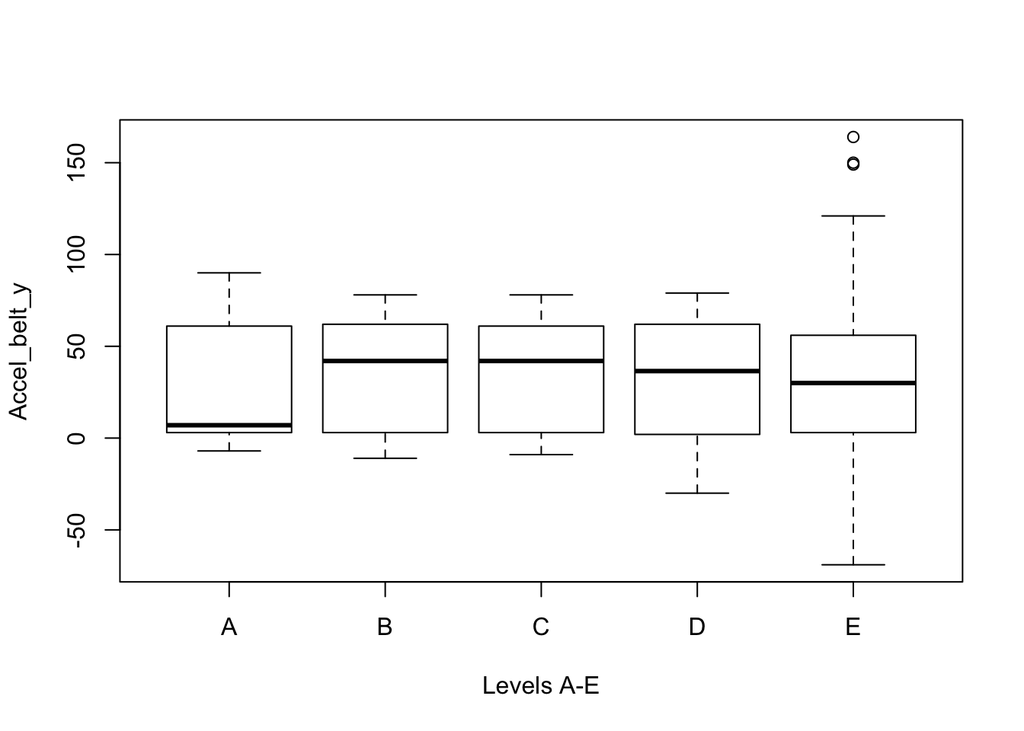

```r
boxplot(accel_belt_y~classe, data=clean_data, xlab="Levels A-E", ylab="Accel_belt_y")
```

Correlation analyses are carried out.

```r
correlations <- abs(cor(clean_data[,-53]))
diag(correlations) <- 0
which(correlations > 0.8,arr.ind=T)
```

```
##                  row col
## yaw_belt           3   1
## total_accel_belt   4   1
## accel_belt_y       9   1
## accel_belt_z      10   1
## accel_belt_x       8   2
## magnet_belt_x     11   2
## roll_belt          1   3
## roll_belt          1   4
## accel_belt_y       9   4
## accel_belt_z      10   4
## pitch_belt         2   8
## magnet_belt_x     11   8
## roll_belt          1   9
## total_accel_belt   4   9
## accel_belt_z      10   9
## roll_belt          1  10
## total_accel_belt   4  10
## accel_belt_y       9  10
## pitch_belt         2  11
## accel_belt_x       8  11
## gyros_arm_y       19  18
## gyros_arm_x       18  19
## magnet_arm_x      24  21
## accel_arm_x       21  24
## magnet_arm_z      26  25
## magnet_arm_y      25  26
## accel_dumbbell_x  34  28
## accel_dumbbell_z  36  29
## gyros_dumbbell_z  33  31
## gyros_forearm_z   46  31
## gyros_dumbbell_x  31  33
## gyros_forearm_z   46  33
## pitch_dumbbell    28  34
## yaw_dumbbell      29  36
## gyros_forearm_z   46  45
## gyros_dumbbell_x  31  46
## gyros_dumbbell_z  33  46
## gyros_forearm_y   45  46
```

### PCA to reduce dimensionality

25 components are needed to retain 95% of the variance

```r
preProc <- preProcess(clean_data[, -53], method="pca", thresh=0.95)
print(preProc)
```

```
##
## Call:
## preProcess.default(x = clean_data[, -53], method = "pca", thresh = 0.95)
##
## Created from 19622 samples and 52 variables
## Pre-processing: principal component signal extraction, scaled, centered
##
## PCA needed 25 components to capture 95 percent of the variance
```

```r
### Separate training and testing data
```

```r
# cross validation 70% for training
inTrain <- createDataPartition(y=clean_data$classe, p=0.7, list=FALSE)
training <- clean_data[inTrain, ]
testing <- clean_data[-inTrain, ]
```

## Building the machine learning model

```r
# Method 1: We are using decision tree
modFit1 <- train(classe~., method="rpart", preProcess="pca", data=training)
print(modFit1)
```

```
## CART
##
## 13737 samples
##    52 predictor
##     5 classes: 'A', 'B', 'C', 'D', 'E'
##
## Pre-processing: principal component signal extraction, scaled, centered
## Resampling: Bootstrapped (25 reps)
##
## Summary of sample sizes: 13737, 13737, 13737, 13737, 13737, 13737, ...
##
## Resampling results across tuning parameters:
##
##   cp          Accuracy   Kappa      Accuracy SD  Kappa SD
##   0.03549995  0.3817047  0.1717310  0.033844439  0.06193794
##   0.06092971  0.3528713  0.1197296  0.026025587  0.04690149
##   0.11738379  0.2825643  0.0000000  0.005698141  0.00000000
##
## Accuracy was used to select the optimal model using  the largest value.
## The final value used for the model was cp = 0.03549995.
```

```r
# Method 2: We are using lda
modFit2 <- train(classe~., method="lda", preProcess="pca", data=training)
print(modFit2)
```

```
## Linear Discriminant Analysis
##
## 13737 samples
##    52 predictor
##     5 classes: 'A', 'B', 'C', 'D', 'E'
##
## Pre-processing: principal component signal extraction, scaled, centered
## Resampling: Bootstrapped (25 reps)
##
## Summary of sample sizes: 13737, 13737, 13737, 13737, 13737, 13737, ...
##
## Resampling results
##
##   Accuracy   Kappa      Accuracy SD  Kappa SD
##   0.5206598  0.3926004  0.006168129  0.00755842
##
##
```

## Examine the results

```r
result1 <- predict(modFit1, newdata=testing)
print(table(result1, testing$classe))
```

```
##
## result1    A    B    C    D    E
##       A 1535  731  970  476  461
##       B    0    0    0    0    0
##       C    0    0    0    0    0
##       D  112  220   40  372  151
##       E   27  188   16  116  470
```

```r
# In sample error
sum(result1==testing$classe)/nrow(testing)
```

```
## [1] 0.4039082
```

```r
result2 <- predict(modFit2, newdata=testing)
print(table(result2, testing$classe))
```

```
##
## result2    A    B    C    D    E
##       A 1114  263  263   79   88
##       B  140  504  101  185  225
##       C  182  207  556  148  156
##       D  224  105   80  475  137
##       E   14   60   26   77  476
```

```r
sum(result2==testing$classe)/nrow(testing)
```

```
## [1] 0.531011
```

## Testing other data

```r
validation <- read.csv("pml-testing.csv")
validate1 <- predict(modFit1, newdata=validation)
validate2 <- predict(modFit2, newdata=validation)
print("Using rpart")
```

```
## [1] "Using rpart"
```

```r
print(validate1)
```

```
##  [1] A A A A A A D A A A A A A A E A A A A E
## Levels: A B C D E
```

```r
print("Using lda")
```

```
## [1] "Using lda"
```

```r
print(validate2)
```

```
##  [1] C A A A A C D D A A A A B A E B A B A B
## Levels: A B C D E
```

## Examine the results

```r
pml_write_files = function(x){
  n = length(x)
  for(i in 1:n){
    filename = paste0("problem_id_",i,".txt")
    write.table(x[i],file=filename,quote=FALSE,row.names=FALSE,col.names=FALSE)
  }
}
```